# Neuro Comorbidities

Meg Hutch

11/16/2020

```r
library(dplyr)
library(ggplot2)
library(tidyr)
library(reshape2)
```

```r
neuro <- read.csv("neuro/neuro_icd.csv")
colnames(neuro)[3] <- "concept_code"

# Import Sites Phase2.1 LocalPatientSummary and LocalPatientObservations files
pt_summary <- read.csv("../nu4ce/Phase2.1/LocalPatientSummary.csv")
obs <- read.csv("../nu4ce/Phase2.1/LocalPatientObservations.csv")

# Import our comorbidity mapping function
source("R/Comorbidity_Mapping_Functions.r")
```

# Data Pre-Processing

## Neuro Cohort

In this initial analysis, we will consider neuro patients as those with a neuro code on the day **of** or **anytime after** their first day of admission.

The neuro_pts dataframe contains neuro patients regardless of whether or not they have a comorbidity/data prior to admission

*Note: We will need to discuss whether we want to include codes assigned on the day of admission as comorbidities.*

```r
obs <- obs %>% filter(concept_type == "DIAG-ICD10")

neuro_pts <- obs %>%
  filter(days_since_admission >= 0)
neuro_pts <- merge(neuro_pts, neuro, by = 'concept_code')

nrow(unique(data.frame(neuro_pts$patient_num)))
```

```
## [1] 711
```

### Neuro patients with prior icd codes

Further subset the neuro patients to those who have data prior to their COVID-19 admission.

```r
neuro_obs_prior <- obs %>%
  filter(days_since_admission < 0) %>%
  filter(patient_num %in% neuro_pts$patient_num)

nrow(unique(data.frame(neuro_obs_prior$patient_num)))
```

```
## [1] 489
```

## Map Comorbidities For the Full Patient and Neuro Cohorts

```r
comorb <- map_charlson_codes(obs)

comorb_neuro <- map_charlson_codes(neuro_obs_prior)
```

The function creates 5 lists:

1. List of comorbidity abbreviations for reference purposes
2. Dataframe indicating which comorbidities were mapped
3. Dataframe of the charlson comorbidity index scores
4. Table 1 to display the % of patients mapped to each comorbidity
5. Dataframe of the specific mapped codes arranged by frequency.

```r
comorb_list_names <- comorb[[1]]
icd_map <- comorb[[2]]
index_scores <- comorb[[3]]
table1 <- comorb[[4]]
mapped_codes_table <- comorb[[5]]
```

## Patients with ICD Codes Prior to COVID-19 Admission

The 2nd list of the returned output from the map_charlson_codes() function will return the comorbidity mapping of all patients with ICD codes prior to admission, regardless of whether or not they had a comorbidity.

Here we can determine how many unique patients we have ICD codes for prior to admission

```r
nrow(data.frame(comorb[[2]]$patient_num))
```

```
## [1] 1825
```

```r
nrow(data.frame(comorb_neuro[[2]]$patient_num))
```

```
## [1] 489
```

## Combined Table 1

The table will include side by side comparison of the comorbidity mappings fo the full patient cohort and neuro patient cohort for those who had prior ICD Codes

```r
full_table1 <- comorb[[4]]
neuro_comorbs_table1 <- comorb_neuro[[4]]

combined_table1 <- left_join(full_table1, neuro_comorbs_table1,
                             by = "Comorbidity")
colnames(combined_table1) <- c("Comorbidity", "Full_Cohort", "Full_Cohort_perc", "Neuro_Cohort", "Neuro_Cohort_perc")


combined_table1$Full_Cohort_perc <- round(combined_table1$Full_Cohort/nrow(pt_summary)*100,2)

combined_table1$Neuro_Cohort_perc <- round(combined_table1$Neuro_Cohort/nrow(pt_summary)*100,2)

combined_table1 <- as.data.frame(combined_table1)

write.csv(combined_table1, "results/table1_combined.csv", row.names = FALSE)
```

## Combine Comorbidity and Neurological Disease Information

The below code will join the comorbidity mappings and the neurological code information, basic demographic and hospital mortality information into one dataframe.

```r
# obtain comorb. mapping from the full cohort
icd_map <- comorb[[2]]

# Create a dataframe of unique neuro code information
obs_neuro_unique <- neuro_pts %>%
  distinct(patient_num, concept_code, Neurological.Disease.Category,
         ICD.10.Description)
#nrow(unique(data.frame(obs_neuro_unique$patient_num)))

# Create matrix with columns for each neurological disease
neuro_matrix <- t(dcast(obs_neuro_unique, concept_code ~ patient_num, value.var="patient_num", length))
neuro_matrix <- as.data.frame(neuro_matrix)
neuro_matrix <- tibble::rownames_to_column(neuro_matrix, "patient_num")
neuro_matrix <- data.frame(lapply(neuro_matrix, as.character), stringsAsFactors=FALSE)
names(neuro_matrix) <- neuro_matrix[1,]
neuro_matrix <- neuro_matrix[-1,]
colnames(neuro_matrix)[1] <- "patient_num"

# merge neuro information to our comorbidity map
neuro_comorbs <- left_join(icd_map, neuro_matrix, by = "patient_num")

# add severity, death, and demographic information
demo <- pt_summary %>%
  select(patient_num, severe, age_group, deceased)

neuro_comorbs <- merge(neuro_comorbs, demo, by = "patient_num")
neuro_comorbs$patient_num <- as.numeric(as.character(neuro_comorbs$patient_num))
```

### Add comorbidity index scores

```r
index_scores <- comorb[[3]]
scores <- index_scores %>% select(patient_num, charlson_score)

neuro_comorbs <- merge(neuro_comorbs, scores, by = "patient_num")
```

### Indicate the Neuro patients

```r
neuro_pt_ids <- neuro_pts %>%
  distinct(patient_num) %>%
  mutate(neuro = 1)

neuro_comorbs <- left_join(neuro_comorbs, neuro_pt_ids, by = "patient_num")
neuro_comorbs$neuro[is.na(neuro_comorbs$neuro)] <- 0
```

```r
#head(neuro_comorbs %>% arrange(desc(patient_num)))
```

# Analysis

## Distribution of Charlson Comorbidity Scores

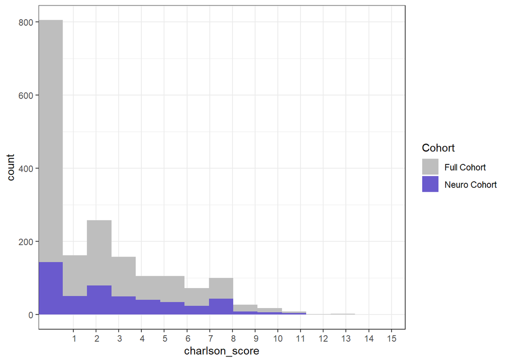

```r
ggplot(neuro_comorbs) +
  geom_histogram(bins = 15, aes(x = charlson_score, fill = "gray")) +
  geom_histogram(bins = 15, data = subset(neuro_comorbs, neuro == "1"), aes(x = charlson_score, fill = "slateblue")) +
  scale_fill_manual(name = "Cohort",
                    values=c("gray", "slateblue"),
                    labels =c("Full Cohort", "Neuro Cohort")) +
  scale_x_discrete(limits = seq(1,15, 1)) +
  theme_bw()
```

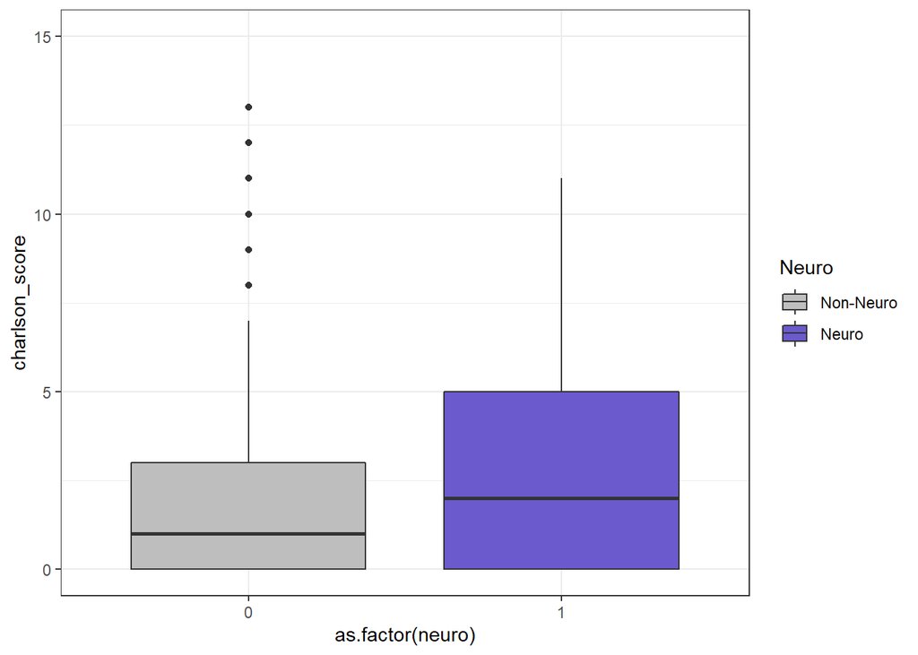

```r
ggplot(neuro_comorbs, aes(x = as.factor(neuro), y = charlson_score, fill = as.factor(neuro))) +
  ylim(0,15) +
geom_boxplot() +
  scale_fill_manual(name = "Neuro",
                    values=c("gray", "slateblue"),
                    labels =c("Non-Neuro", "Neuro")) +
  theme_bw()
```

```r
#nrow(data.frame(unique(neuro_comorbs$patient_num)))
```

## Median and IQR of Charlson Scores

```r
aggregate(charlson_score ~ neuro, FUN = "median", neuro_comorbs)
```

```
##   neuro charlson_score
## 1     0              1
## 2     1              2
```

```r
aggregate(charlson_score ~ neuro, FUN = "summary", neuro_comorbs)
```

```
##   neuro charlson_score.Min. charlson_score.1st Qu. charlson_score.Median
## 1     0            0.000000               0.000000              1.000000
## 2     1            0.000000               0.000000              2.000000
##   charlson_score.Mean charlson_score.3rd Qu. charlson_score.Max.
## 1            1.854790               3.000000           13.000000
## 2            2.805726               5.000000           11.000000
```

## Wilcoxon Test

```r
neuro_group0 <- neuro_comorbs %>% filter(neuro == 1)
non_neuro_group0 <- neuro_comorbs %>% filter(neuro == 0)

wilcox.test(neuro_group0$charlson_score, non_neuro_group0$charlson_score)
```

```
##
##  Wilcoxon rank sum test with continuity correction
##
## data:  neuro_group0$charlson_score and non_neuro_group0$charlson_score
## W = 400205, p-value = 1.032e-14
## alternative hypothesis: true location shift is not equal to 0
```

## Charlson Scores by Neuro Diagnosis

Here we will use the obs_neuro_unique dataframe in contrast to our neuro_comorbs dataframe as the former is in long format

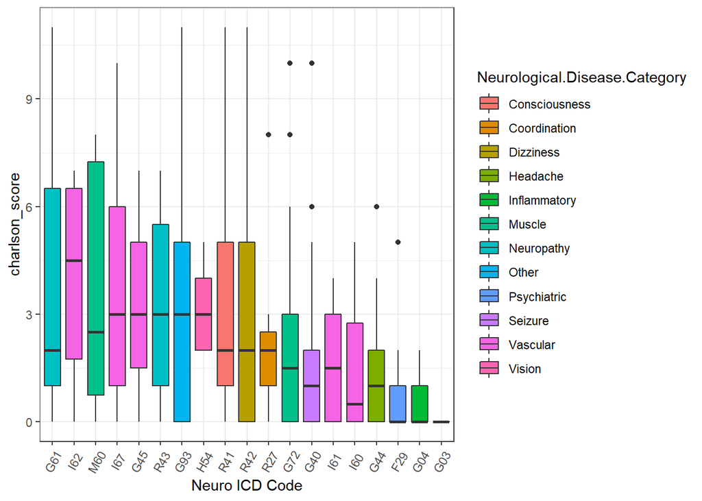

```r
scores$patient_num <- as.numeric(as.character(scores$patient_num))
scores_neuro <- left_join(obs_neuro_unique, scores, by = "patient_num")
scores_neuro <- left_join(scores_neuro, demo, by = "patient_num")

p1 <- ggplot(scores_neuro, aes(x = reorder(concept_code, -charlson_score, na.rm = TRUE), y = charlson_score, fill = Neurological.Disease.Category)) +
  geom_boxplot() +
  xlab("Neuro ICD Code") +
  theme_bw()

p1 + theme(axis.text.x = element_text(angle = 60, vjust = 0.5))
```

## Charlson Scores by Severity

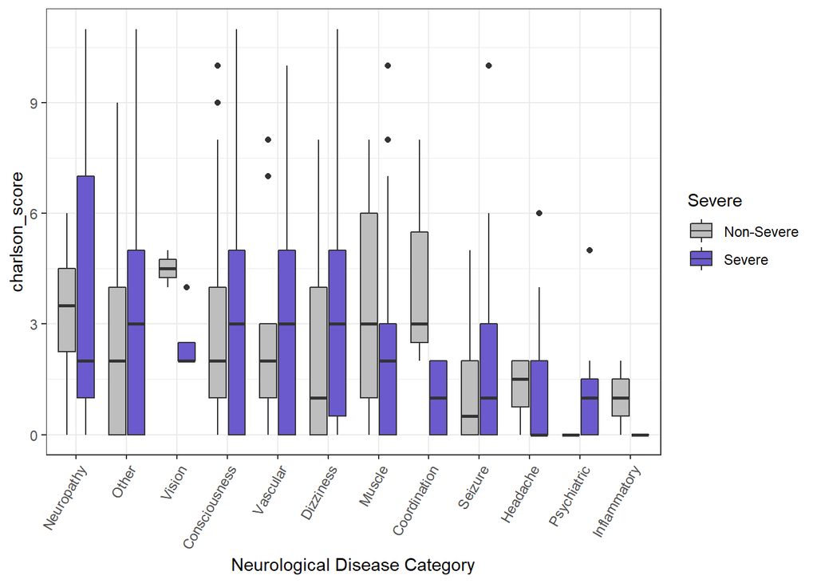

```r
p2 <- ggplot(scores_neuro, aes(x = reorder(Neurological.Disease.Category, -charlson_score, na.rm = TRUE), y = charlson_score, fill = as.factor(severe))) +
  geom_boxplot() +
  xlab("Neurological Disease Category") +
  scale_fill_manual(name = "Severe",
                    values=c("gray", "slateblue"),
                    labels =c("Non-Severe", "Severe")) +
  theme_bw()

p2 + theme(axis.text.x = element_text(angle = 60, hjust = 1))
```

## Comorbidities Among Neuro vs Non-Neuro Patients

```r
comorb_long <- neuro_comorbs[, 1:18]
comorb_long <- gather(comorb_long, comorbidity, comorbidity_yes, MI:HIV, factor_key=TRUE)

# add neuro identifier and charlson_score
comorb_long <- left_join(comorb_long, neuro_pt_ids, by = "patient_num")
comorb_long <- left_join(comorb_long, scores, by = "patient_num")
comorb_long$neuro[is.na(comorb_long$neuro)] <- 0

# how many neuro patients have a comorbidity
comorb_long_neuro <- comorb_long %>%
  group_by(patient_num) %>%
  filter(neuro == 1) %>%
  filter(comorbidity_yes == 1) %>%
  slice(1L)
nrow(comorb_long_neuro)
```

```
## [1] 345
```

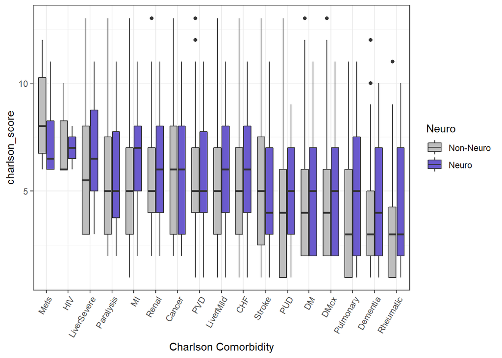

```r
p3 <- ggplot(comorb_long %>% filter(!comorbidity_yes == 0), aes(x = reorder(comorbidity, -charlson_score, na.rm = TRUE), y = charlson_score, fill = as.factor(neuro))) +
  geom_boxplot() +
  scale_fill_manual(name = "Neuro",
                    values=c("gray", "slateblue"),
                    labels =c("Non-Neuro", "Neuro")) +
  xlab("Charlson Comorbidity") +
  theme_bw()

p3 + theme(axis.text.x = element_text(angle = 60, hjust = 1))
```

## Wilcoxon Test comparing comorbidities of non-neuro vs neuro patients

```r
comorb_wilcox_func <- function(df, comorb) {

  df <- df %>%
    filter(comorbidity == comorb & comorbidity_yes == 1)

  neuro <- df %>% filter(neuro == 1)

  non_neuro <- df %>% filter(neuro == 0)

  results = wilcox.test(neuro$charlson_score,
                        non_neuro$charlson_score)$p.value

}

comorbs <- c("MI", "CHF", "PVD", "Stroke", "Dementia", "Pulmonary",
             "Rheumatic", "PUD", "LiverMild", "DM", "DMcx", "Paralysis",
             "Renal", "Cancer", "LiverSevere", "Mets", "HIV")


wilcox_list = list()

for (i in comorbs) {
    result <- comorb_wilcox_func(comorb_long, i)
    wilcox_list[[i]] <- result # add it to your list
}
result_list = as.data.frame(do.call(rbind, wilcox_list))
colnames(result_list) <- "p.value"

# organize by significance
result_list <- result_list %>% arrange(p.value)
print(result_list)
```

```
##                 p.value
## MI          0.001714464
## CHF         0.015347105
## Pulmonary   0.015711225
## Mets        0.154298768
## Renal       0.164344161
## LiverMild   0.194543244
## DM          0.251719080
## DMcx        0.251719080
## LiverSevere 0.257121214
## Stroke      0.479962806
## Rheumatic   0.497802741
## Dementia    0.503476618
## PUD         0.641548708
## Cancer      0.686604746
## Paralysis   0.894338213
## PVD         0.902442883
## HIV         1.000000000
```

```r
median_list = list()

for (i in comorbs) {

    df <- comorb_long %>%
      filter(comorbidity_yes == 1) %>%
      filter(comorbidity == i)

    result <- aggregate(charlson_score ~ neuro, FUN = "summary", df)
    result <- as.data.frame(result)

    median_list[[i]] <- result

}
median_list = do.call(rbind, median_list)
list_names <- row.names(median_list)

m1 <- median_list[[1]]
m2 <- median_list[[2]]
median_list <- cbind(m1, m2)
row.names(median_list) <- list_names
colnames(median_list)[1] <- "Neuro"
```

## Outcomes

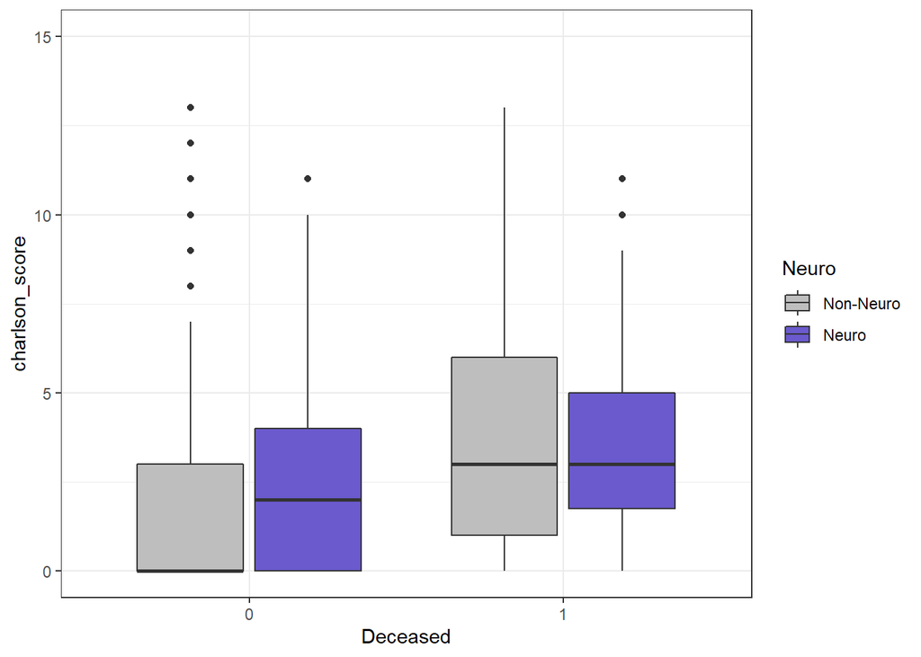

```r
ggplot(neuro_comorbs, aes(x = as.factor(deceased), y = charlson_score, fill = as.factor(neuro))) +
  ylim(0,15) +
geom_boxplot() +
  xlab("Deceased") +
  scale_fill_manual(name = "Neuro",
                    values=c("gray", "slateblue"),
                    labels =c("Non-Neuro", "Neuro")) +
  theme_bw()
```

```r
aggregate(charlson_score ~ neuro + deceased, FUN = "summary", neuro_comorbs)
```

```
##   neuro deceased charlson_score.Min. charlson_score.1st Qu.
## 1     0        0            0.000000               0.000000
## 2     1        0            0.000000               0.000000
## 3     0        1            0.000000               1.000000
## 4     1        1            0.000000               1.750000
##   charlson_score.Median charlson_score.Mean charlson_score.3rd Qu.
## 1              0.000000            1.704271               3.000000
## 2              2.000000            2.659674               4.000000
## 3              3.000000            3.821053               6.000000
## 4              3.000000            3.850000               5.000000
##   charlson_score.Max.
## 1           13.000000
## 2           11.000000
## 3           13.000000
## 4           11.000000
```

## Neuro Patients and Outcomes

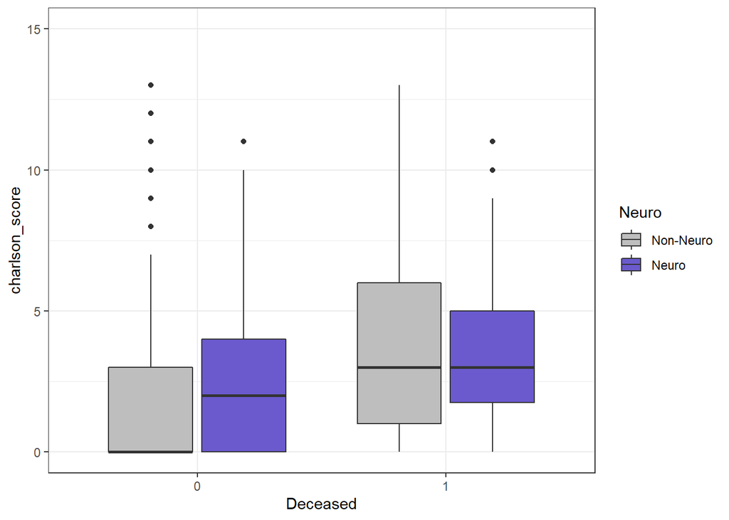

```r
neuro_group <- neuro_comorbs %>% filter(neuro == 1)
non_neuro_group <- neuro_comorbs %>% filter(neuro == 0)

ggplot(neuro_comorbs, aes(x = as.factor(deceased), y = charlson_score, fill = as.factor(neuro))) +
  ylim(0,15) +
geom_boxplot() +
  xlab("Deceased") +
  scale_fill_manual(name = "Neuro",
                    values=c("gray", "slateblue"),
                    labels =c("Non-Neuro", "Neuro")) +
  theme_bw()
```

```r
aggregate(charlson_score ~ neuro + deceased, FUN = "summary", neuro_comorbs)
```

```
##   neuro deceased charlson_score.Min. charlson_score.1st Qu.
## 1     0        0            0.000000               0.000000
## 2     1        0            0.000000               0.000000
## 3     0        1            0.000000               1.000000
## 4     1        1            0.000000               1.750000
##   charlson_score.Median charlson_score.Mean charlson_score.3rd Qu.
## 1              0.000000            1.704271               3.000000
## 2              2.000000            2.659674               4.000000
## 3              3.000000            3.821053               6.000000
## 4              3.000000            3.850000               5.000000
##   charlson_score.Max.
## 1           13.000000
## 2           11.000000
## 3           13.000000
## 4           11.000000
```

### Additional Notes:

Neuro Codes: G04, G45, G46, I60, 161, 162, and 167 will map to comorbidities. An important consideration is that we don’t want to confuse comorbidities for complications of hospital stay/COVID-19

The below will assess how many on these neuro comorbidity codes occurred on the day of admission and how many neuro codes in general are on the day of admission.

*Note: This is just for data exploration right now, we are going to initially just assume that any codes prior to the COVID-19 admission are comorbidities*

```r
neuro_comorb_codes <- c("G04", "G45", "G46",
                        "I60", "161", "162",
                        "167")

neuro_comorb_on_admission <- obs %>%
  filter(days_since_admission == 0) %>%
  filter(concept_code %in% neuro_comorb_codes) %>%
  select(patient_num, concept_code) %>%
  distinct()
nrow(unique(data.frame(neuro_comorb_on_admission)))
```

```
## [1] 4
```

```r
nrow(unique(data.frame(neuro_comorb_on_admission$patient_num)))
```

```
## [1] 4
```